# moveStan

**Tools for movement models using STAN (mc-stan.org)**

**1) Posterior checks for movement model building**

Two types of posterior checks are currently available:

1. Posterior checks for angluar only predictions

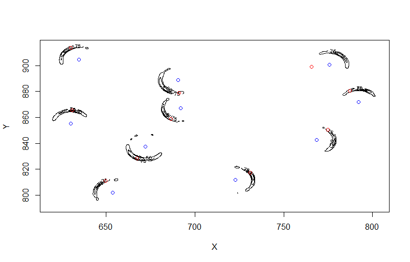

   For each point along a movement track the model is used to make predictions about the angle the moving object will take. The discrepency between the predicted (density contours) and observed angle (red points) can then be compared.
2. Posterior checks for position predictions (angle and distance)

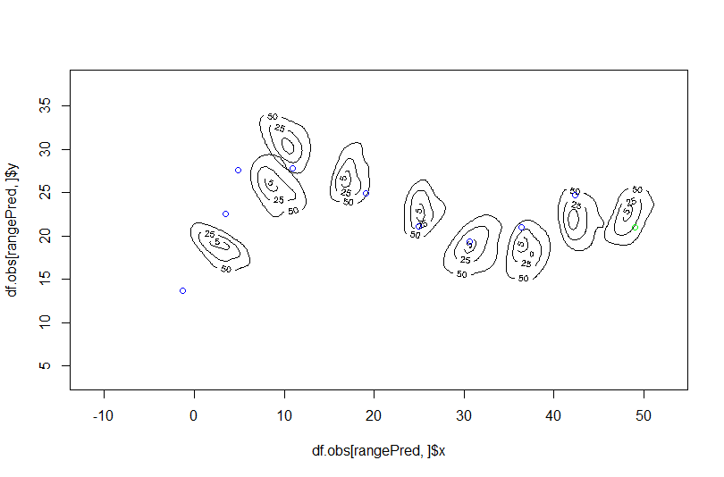

   For each point along a movement track the model is used to make predictions about the subsequent position the movement object will be found. The discrepency between the predicted (density contours) and the observed positions can then be compared.

**2) Simulate movement using fit models in different environments**

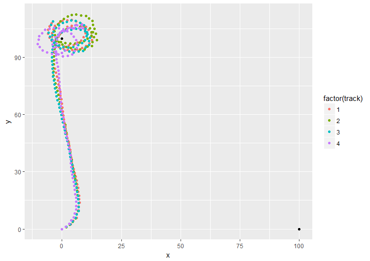

The above image was generated by simulating 4 tracks from a movement model fit to made up data. The made up data contained short movement tracks where there was a bias towards females in a group. The novel environment placed a female at one point (0,100) and a male at (100,0) and used the model to simulate predicted motions of the focal animal. Multiple tracks (in this case 4 tracks) can be generated to gain an idea of the uncertainty in the simulated predictions.